# ST590 - Project 2

Authored by Group 13 - Dave Bergeron, Xavier Genelin, and Maksim Nikiforov

## Introduction

Netflix is "one of the world's leading entertainment services", providing access to TV series, movies, documentaries, and mobile games to over 200 million subscribers (*Netflix - Overview - Profile*, n.d.). Within the company, "[d]ata is used to inform a wide range of questions — ‘How can we make the product experience even better?’, ‘Which shows and films bring the most joy to our members?’, ‘Who can we partner with to expand access to our service in new markets?’ (Jackman & Reddy, 2020). The company's data scientists, engineers, analysts, and visualizers regularly interact with internal business verticals - product, content, membership, studio, marketing, and platform - to analyze viewership patterns, estimate the sizes of target audiences for content, and invest accordingly in that content (Ufford & Kelley, 2018). They work on optimization problems to determine where to cache content to remain "as close as possible to the end user and consequently to send as few bytes as possible across the wider internet" (Berglund, 2017). Data teams are also critical to providing a near real-time and consistent user experience (Gulati & Gevorkyan, 2022), continuously delivering incremental changes (*Morgan Stanley Technology, Media & Telecom Conference*, 2022), and quickly troubleshooting problems (Srivastava & Mayworm, 2022). They do this at mind-boggling scale; in 2018, Netflix was ingesting more than 1 trillion streaming events *per day* and filtering it into a data warehouse that contained over 100 petabytes of data (Ufford & Kelley, 2018). The sections below discuss challenges that result from data of this size and the technical architecture that keeps Netflix operational.

[figure not shown]

Responsibilities of data professionals at Netflix.  
[Image Source](https://netflixtechblog.com/analytics-at-netflix-who-we-are-and-what-we-do-7d9c08fe6965)

## Data ingestion

According to Michelle Ufford, who led the Big Data Tools team at Netflix, Netflix continuously tracks user activity. "As soon as you log in...we're tracking what is the content that we are showing you, because every single member, and every single profile, is completely 100% personalized" (Ufford & Kelley, 2018). Events such as playing video, pausing video, quality changes, and content switching are streamed continuously to Netflix, and ingestion systems must handle "spikes due to a popular show coming online or unexpected failure scenarios" (Xu, 2018). When systems do fail, they must recover quickly and automatically or re-route traffic to servers in other clusters. Additionally, engineers must assign staleness thresholds to filter outdated events, and some events must be prioritized above others. Gulati et al. point out that a "member-triggered event such as 'change in a profile’s maturity level' should have a much higher priority than a 'system diagnostic signal'" (Gulati & Gevorkyan, 2022).

[figure not shown]

The streaming architecture of Pensive, an auto-diagnosis and remediation system for data platforms at Netflix.  
[Image Source](https://netflixtechblog.com/auto-diagnosis-and-remediation-in-netflix-data-platform-5bcc52d853d1)

To accept and process streaming data and to address the requirements above, Netflix has implemented a number of disparate systems, one of which is an ingestion platform called "Keystone" that leverages Apache Kafka and Apache Flink (Xu, 2018). As a distributed event-streaming platform, Kafka can capture incoming data from a multitude of sensors, mobile devices, and software applications and store it durably as event logs (or "topics") (*Apache Kafka*, n.d.). Flink, a distributed in-memory processing engine, can consume Kafka's topics as input for ETL (extract, transform, load) pipelines to aggregate and enrich streaming data with SQL, Java, Scala, or Python (*Data Pipelines & ETL*, n.d.). Kafka and Flink have also been incorporated into an auto-diagnosis and remediation system called "Pensive" to monitor metrics, diagnose errors, automatically deploy new Flink clusters, increase and decrease the retention size of Kafka topics, or alert engineers about ongoing problems (Srivastava & Mayworm, 2022). The owners of Pensive hope to augment the platform's business rules engine with additional machine learning capabilities to classify a greater number of errors and to help tune data processing platforms such as Apache Spark. Other service owners at Netflix rely on Amazon Simple Queue Service (SQS), which underpins solutions such as RENO (the Rapid Event Notification System) that are responsible for the “Personalized Experience Refresh” on end-user devices (Gulati & Gevorkyan, 2022). Amazon SQS is a managed messaging service, meaning that the onus of maintenance is largely on Amazon, and the service claims to support "a nearly unlimited number of transactions per second" to help Netflix scale and address rapidly-growing queues (*Amazon SQS Features | Message Queuing Service | AWS*, n.d.). Regardless of which open-source or cloud-native event service Netflix uses, they all require one thing - copious amounts of storage.

# Data storage and processing

In addition to the "data in motion" systems such as Kafka and Flink, discussed in the previous section, which platforms make up Netflix's "data at rest" infrastructure? In other words, where does Netflix store petabytes of data and how does the company derive insights from it? Risianto et al. have listed the cloud-based data warehouse and data lake vendor Snowflake in Netflix's product stack, as well as Apache Cassandra and Apache Druid (Risianto et al., 2020). Netflix engineers use Cassandra, a NoSQL database, to store time series data - "over 140 million hours of content per day" - for its viewers (Duvedi et al., 2018). Cassandra also holds records of notifications sent by RENO They also use the Druid analytics database to quickly store and query "over 2 million events per second" in order to "understand and quantify how seamlessly users’ devices are handling browsing and playback" (Sykes, 2020). However, one product stands above the rest in its importance to Netflix; Amazon Simple Storage Service (S3).

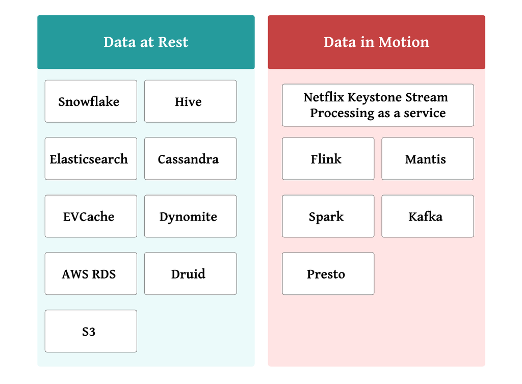

A partial overview of Netflix's data platform landscape.  
[Image Source](https://netflixtechblog.com/byte-down-making-netflixs-data-infrastructure-cost-effective-fee7b3235032)

According to Kurt Brown, who managed the Netflix data platform in 2017, Amazon S3 serves as the "central data hub" and the "source of truth" for cost data and data processing engines (Brown, 2017). Amazon S3 is a cloud-based solution from Amazon Web Services which allows customers to store "any type and amount of data" durably, version it, and control granular access to it (*Amazon Simple Storage Service (S3) — Cloud Storage — AWS*, n.d.). Amazon S3 and the data it holds serve as one of the inputs for Apache Spark, which has been billed as a "unified engine" for processing streaming and batch data in memory and on disk across thousands of nodes (Zaharia et al., 2016). Matei Zaharia, one of Spark's originators, developed the project to "make data processing more accessible" to scientists and analysts who were accustomed to working with languages such as Python, Scala, and SQL and their associated libraries, rather than the arguably more difficult languages such as Java (Moses & Vorwerck, 2020). Kurt Brown has cited Spark's support for both Scala and Python as a major contributor to the widespread adoption of Spark at Netflix (Brown, 2017).

Kurt estimated that, at the time of his presentation in 2017, Netflix was running "low" tens of thousands of big data processing jobs, 25%-40% of which leveraged Spark (Brown, 2017). What constituted the remaining portion of these workloads? According to Ryan Blue, a former software engineer at Netflix, the company was "mostly a Pig shop" with "some" Hive jobs in the mix (Blue, 2019). Apache Pig had been developed by Yahoo to allow users to write programs in a high-level language, "Pig Latin", and to execute them in parallel on Hadoop clusters (*Welcome to Apache Pig!*, n.d.). While the high-level abstraction of Pig Latin makes it easier than Java, the language can still be difficult to use and difficult to optimize (Blue, 2019). Apache Hive serves a similar purpose as Pig, but provides support for the more commonly used SQL language (*Apache Hive*, n.d.). However, various benchmarks have shown that Spark and Spark SQL outperform Hive (Mavridis & Karatza, 2017). Partly for this reason, by 2019, the total number of daily job executions at Netflix had grown to "high" tens of thousands and more than 90% were powered by the Spark engine (Blue, 2019).

# Data visualization

Data visualization at Netflix is "the end-to-end process of finding and processing raw data, weaving in analytics and business insights, and finally visually telling a story tailored to the audience" (Zhu, 2018). Netflix uses a wide range of data visualization tools such as Tableau, Power BI, and Looker while also creating their own from scratch that some of those different tools may not offer though something like JavaScript web apps (Jackman & Reddy, 2020). With the vast amount of data available at Netflix and the constant usage from their users, they need to make informed decisions on what is happening currently. The dashboards have dynamic visuals that use the most recent data possible with some being updated in near real-time (Mavinkurve et al., 2017). The image below is an example of a visual that Netflix would use that uses real-time data by using fake data.

[figure not shown]

The dashboard will have different components that allows the user to adjust the visual to what they are interested in seeing, along with a navigation bar to allow a variety of pages to be located in one place. In the example above, the visual provides a user real-time information about incidents users are having with the service. This can allow the business to easily monitor daily activities in real-time (Penamatsa, n.d.).

Netflix uses data visualization to monitor user activity which can also can help aide the company in what type of shows to create while also seeing which current series they should extend based on what users are actually watching. This strategy has made Netflix renew over 80% of their seasons, compared to the average 25% in the industry (Penamatsa, n.d.). By looking at what users are viewing, Netflix is also able to target different audiences with TV and movie trailers. Netflix produced 10 different trailers for the first season of the show House of Cards, and showed the trailers to different audiences. This was different than their usual strategy of only creating one or two trailers for promotion (Divakaran, 2017). For example, if an audience was a fan of Kevin Spacy (the show's main protagonist) they would see a trailer that he was the main focus of while another audience may prefer shows/movies with female protagonists, so they would be shown a trainer that showcased the female characters in the show

# Data buffering

## First, what is data buffering?

When data is in transit it requires temporary storage. A data buffer is a region of a memory used to temporarily store data in transit. When data is pulled from an input device or when data is pushed through an output it is stored in a buffer. The buffering process enables data to smoothly travel even when speed between input and output don’t match. The buffer adjusts the timing to create a seamless transit process. Consumers are often familiar with “buffering errors” and this is typically attributed to a data speed error - either the data is going to slow or the internet connection is too slow for the data. Interestingly, Netflix and Google both offer speed tests and the reasons they do so are worth a closer look - if the provider can force consumers to focus on internet speed then the provider’s role in buffering is less prominent. As Alexander notes, buffering induces anxiety and speed tests are an attempt to calm users with an explanation (Elkins, 2018).

Alexander, describes the user experience with buffering, “Buffering, namely the need to preload data before streaming a video or audio file, epitomizes the oft-ignored ruptures and disruptions of digital engagement. Whereas buffering is often read as “noise” or as a technical nuisance awaiting a solution, a closer look can challenge our notion of mediation, immersion, and control" (Alexander, 2017).

The first reply on Netflix’s help page regarding data buffering points the user to their own internet speed: “If your TV show or movie loads slowly or you experience buffering or rebuffering, you may have a weak or unstable connection to the internet" (*TV Show or Movie Loads Slowly or Keeps Buffering*, n.d.).

Data stored in a data buffer are stored in a physical storage - even if a digital buffer is used, it drives to a location in the physical memory (“Data Buffer,” 2022).

## Buffering Challenges for Netflix

Netflix has developed two internet speed tests, ISP Speed Index and Fast. com. Since speed is the core responsibility of the buffer these tests are intertwined with how Netflix approaches buffering. Buffering is needed when data is either too slow or the internet is too slow - a buffer helps match the speeds so data can travel smoothly. By suggesting internet speed is the issue Netflix can be diverting attention away from the buffering process and focusing on one part of the transit flow.

Netflix collects data to inform programming and buffer data is not excluded. The rebuffer rate (delays due to buffering) is captured (Marr, 2015).

## How Netflix Manages Data Buffering

Through its “Keystone Pipeline” Netflix processes 500 billion events per day and utilizes Kafka clusters to process billions of messages daily. Apache Kafka is a platform that can support applications to be developed that process a high volume of real-time data (*Netflix*, n.d.). Kafka works by structuring applications so they can push data seamlessly, store data at rest accurately, process quickly, and process accurately.

The diagram below shows how Apache Kafka fits in Netflix’s Keystone pipeline:

[figure not shown]

# Data Routing

Netflix streams more than 125 million hours of video daily and serves over 220 million paid subscribers. Data processed by Netflix is in the billions. Prior to 2018 Netflix’s “Keystone data pipeline” lived with the `Apache Samza framework`, but in 2018 it was replaced by `Apache Flink`. Keystone data pipeline processes 12PB of data per day into its `S3` data warehouse. Flink runs on the AWS cloud. And Netflix has designed some workarounds for common AWS challenges: 1) prevent data from being stored in the same cluster by adjusting prefixes in the log file, 2) Fink takes snapshots and sends to `S3` to keep consistent but these files are small and not optimal for `S3` so Netflix engineers designed a memory threshold to bump the file size up, and 3) adjusting the timing on processing metadata requests. All of these engineering tweaks enable the Keystone data pipeline to thrive in `Flink` (Woodie, 2018).

## What is Apache Flink?

`Apache Flink` is a stream processing system for stateful computations. Data is a stream of events - stateful processing means a state is shared between events enabling current events to be influenced by past events. Apache Fink is designed to process bounded and unbounded data streams:

`unbounded`: continuous streams that require ongoing processing based on a hierarchy such as order in which events occurred.

`bounded`: streams with fixed end and start points that can be processed in “batches”. The term batch processing refers to bounded data that can be processed once all data has been collected (*Apache Flink: What Is Apache Flink? — Architecture*, n.d.).

[figure not shown]

## Challenges Netflix Faces

Even with the capabilities `Apache Flink` brings, Netflix engineers still face challenges. The Netflix data engineering team discovered a process that while not negatively imparting data flow did increase costs. `Flink` operators making metadata requests in the Keystone Router resulted in the request passing two paths -one with a slash at the end of the pathname for necessary compatibility with HDFS and one without a slash. This design meant that at the end of the pipeline half of the jobs would terminate without `S3` files being written. Netflix calculated this resulted in 13,000 metadata requests being sent from task managers without writing any `S3` files, while not creating any data issues this was unproductive. Netflix engineers worked with `Flink` to call the Checkpoint Stream Factory on demand when the operator is first initialized instead of every 30 seconds (Woodie, 2018).

## Bibliography

Alexander, N. (2017). Rage against the Machine: Buffering, Noise, and Perpetual Anxiety in the Age of Connected Viewing. *Cinema Journal*, *56*(2), 1–24. https://doi.org/10.1353/cj.2017.0000

*Amazon Simple Storage Service (S3) — Cloud Storage — AWS*. (n.d.). Amazon Web Services, Inc. Retrieved March 27, 2022, from https://aws.amazon.com/s3/faqs/

*Amazon SQS Features | Message Queuing Service | AWS*. (n.d.). Amazon Web Services, Inc. Retrieved March 28, 2022, from https://aws.amazon.com/sqs/features/

*Apache Flink: What is Apache Flink? — Architecture*. (n.d.). Retrieved March 11, 2022, from https://flink.apache.org/flink-architecture.html

*Apache Hive*. (n.d.). Retrieved March 27, 2022, from https://hive.apache.org/?msclkid=2fef1f57ae1d11ec8a9ec37523a0ad0b

*Apache Kafka*. (n.d.). Apache Kafka. Retrieved March 11, 2022, from https://kafka.apache.org/documentation/#intro_concepts_and_terms

Berglund, A. (2017, May 25). *How Data Science Helps Power Worldwide Delivery of Netflix Content*. Medium. https://netflixtechblog.com/how-data-science-helps-power-worldwide-delivery-of-netflix-content-bac55800f9a7

Blue, R. (2019, May). *Migrating to Apache Spark at Netflix*. Databricks. https://databricks.com/session/migrating-to-apache-spark-at-netflix?msclkid=2011f4c3ae1911ec826ffef6080d42f0

Brown, K. (2017, March 13). *The Netflix data platform: Now and in the future - Kurt Brown (Netflix)*. O’Reilly Online Learning. https://learning.oreilly.com/videos/strata-hadoop/9781491976166/9781491976166-video301110/

Data buffer. (2022). In *Wikipedia*. https://en.wikipedia.org/w/index.php?title=Data_buffer&oldid=1074629100

*Data Pipelines & ETL*. (n.d.). Retrieved March 11, 2022, from //nightlies.apache.org/flink/flink-docs-master/docs/learn-flink/etl/

Divakaran, S. (2017, August 13). *Inside Netflix’s Content Strategy*. Digital Uncovered. https://digitaluncovered.com/inside-netflixs-content-strategy/

Duvedi, K., Li, J., Garg, D., & Fisher-Ogden, P. (2018, January 25). *Scaling Time Series Data Storage — Part I*. Medium. https://netflixtechblog.com/scaling-time-series-data-storage-part-i-ec2b6d44ba39

Elkins, E. (2018). Powered by Netflix: speed test services and video-on-demand’s global development projects. *Media, Culture & Society*, *40*(6), 838–855. https://doi.org/10.1177/0163443718754649

Gulati, A., & Gevorkyan, D. (2022, February 18). *Rapid Event Notification System at Netflix*. Medium. https://netflixtechblog.com/rapid-event-notification-system-at-netflix-6deb1d2b57d1

Jackman, M., & Reddy, M. (2020, December 18). *Analytics at Netflix: Who we are and what we do*. Netflix Technology Blog. https://netflixtechblog.com/analytics-at-netflix-who-we-are-and-what-we-do-7d9c08fe6965

Marr, B. (2015, March 26). *The Amazing Ways Netflix Uses Big Data To Drive Success | LinkedIn*. https://www.linkedin.com/pulse/amazing-ways-netflix-uses-big-data-drive-success-bernard-marr/

Mavinkurve, R., Becker, J., & Christensen, B. (2017, April 19). *Improving Netflix’s Operational Visibility with Real-Time Insight Tools*. Medium. https://netflixtechblog.com/improving-netflixs-operational-visibility-with-real-time-insight-tools-ab5e7af062e5

Mavridis, I., & Karatza, H. (2017). Performance evaluation of cloud-based log file analysis with Apache Hadoop and Apache Spark. *Journal of Systems and Software*, *125*, 133–151. https://doi.org/10.1016/j.jss.2016.11.037

*Morgan Stanley Technology, Media & Telecom Conference*. (2022, March 8). Investor Events. https://morganstanley.webcasts.com/viewer/event.jsp?ei=1534749&tp_key=67fe6fb0ba

Moses, B., & Vorwerck, M. (2020, November 12). *Bringing Reliable Data And AI To The Cloud: A Q&A With Databricks’ Matei Zaharia*. Monte Carlo Data. https://www.montecarlodata.com/conversation-with-databricks-matei-zaharia/

*Netflix - Overview - Profile*. (n.d.). Retrieved March 11, 2022, from https://ir.netflix.net/ir-overview/profile/default.aspx

*Netflix: How Apache Kafka turns data from millions into intelligence*. (n.d.). Merit Data Tech. Retrieved March 28, 2022, from https://www.meritdata-tech.com/resources/blog/digital-engineering-solutions/netflix-apache-kafka-business-intelligence/

Penamatsa, V. (n.d.). *Data visualization, the key to Netflix’s success: an analysis*. Retrieved March 16, 2022, from https://www.toucantoco.com/en/blog/data-visualization-the-key-to-netflixs-success-an-analysis

Risianto, T., Reddy, B., Sahni, T., & Park, A. (2020, July 11). *Byte Down: Making Netflix’s Data Infrastructure Cost-Effective*. Medium. https://netflixtechblog.com/byte-down-making-netflixs-data-infrastructure-cost-effective-fee7b3235032

Srivastava, V., & Mayworm, M. (2022, January 20). *Auto-Diagnosis and Remediation in Netflix Data Platform*. Medium. https://netflixtechblog.com/auto-diagnosis-and-remediation-in-netflix-data-platform-5bcc52d853d1

Sykes, B. (2020, March 3). *How Netflix uses Druid for Real-time Insights to Ensure a High-Quality Experience*. Medium. https://netflixtechblog.com/how-netflix-uses-druid-for-real-time-insights-to-ensure-a-high-quality-experience-19e1e8568d06

*TV show or movie loads slowly or keeps buffering*. (n.d.). Help Center. Retrieved March 28, 2022, from https://help.netflix.com/en/node/230

Ufford, M., & Kelley, K. (2018). *Notebooks at Netflix: From analytics to engineering (sponsored by Netflix) - Michelle Ufford (Netflix) Kyle Kelley (Netflix)*. O’Reilly Online Learning. https://learning.oreilly.com/videos/jupytercon-new-york/9781492025818/9781492025818-video322538/

*Welcome to Apache Pig!* (n.d.). Retrieved March 27, 2022, from https://pig.apache.org/index.html

Woodie, A. (2018, April 30). *How Netflix Optimized Flink for Massive Scale on AWS*. Datanami. https://www.datanami.com/2018/04/30/how-netflix-optimized-flink-for-massive-scale-on-aws/

Xu, Z. (2018, September 10). *Keystone Real-time Stream Processing Platform*. Medium. https://netflixtechblog.com/keystone-real-time-stream-processing-platform-a3ee651812a

Zaharia, M., Xin, R. S., Wendell, P., Das, T., Armbrust, M., Dave, A., Meng, X., Rosen, J., Venkataraman, S., Franklin, M. J., Ghodsi, A., Gonzalez, J., Shenker, S., & Stoica, I. (2016). Apache Spark: a unified engine for big data processing. *Communications of the ACM*, *59*(11), 56–65. https://doi.org/10.1145/2934664

Zhu, H. (2018, August 3). *Day In The Life Of A Data Visualization Engineer @ Netflix*. Medium. https://medium.com/hasbrain/day-in-life-of-a-data-visualization-engineer-netflix-d99150e8275c